# St number of Von Kàrman vorticies, replicated at home

Magnus J. Moldekleiv

### Motivation

As I was doing the course on Turbulent Flows, I wanted to see if I could replicate a turbulent classic - the Von Kàrman vorticies - at home. The main idea was to leverage Galilean invariance - i.e invariance to inertial reference frames - to cheaply investigate the vortex shedding frequency behind a cylinder by moving the cylinder itself instead of flowing water around it, as is commonly done.

### The *“experimental”* experimental setup

For a suitable and available container, I chose a bathtub. This was filled with water, to which a small amount of startch (potato-flour) and some blue food-dye was added, as I (after some trial and error) found this produced quite nice and visible vorticies. To try and get a smooth pull, I decided to try a gravity-assisted pull - i.e using an adjustable weight (yellow water bottle) tied to the cylinder with some fishing line. This explains the clothes rack in the image below, as I needed some way as to redirect the string forces, with the smooth metal of the rack acting as makeshift pullies. A metre-stick was added to serve as a reference for the velocity estimation from the videos.

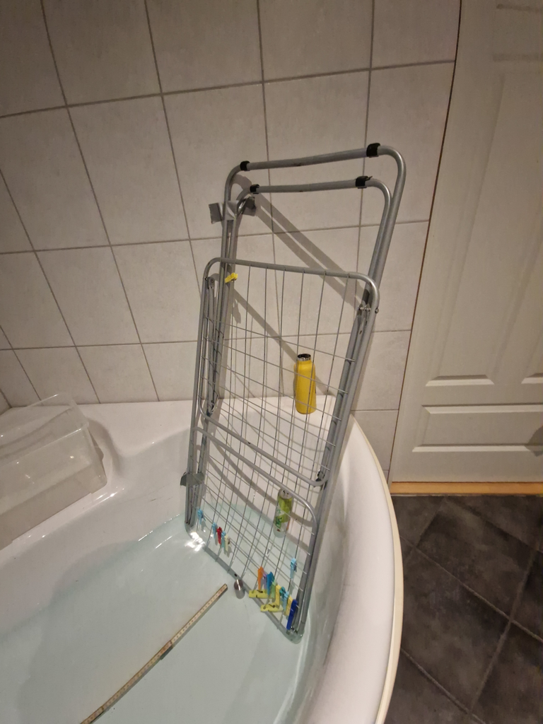

Note that due to problems with friction against the bottom of the tub, runs were performed with both gravity pull and by pulling the cylinder by hand against the resistance of the bottle (it is easier to pull smooth if it is against a resistance).

### Limitations and run selections

There are many possible sources of noise in the data, here are a few that I can think of: - We could have viscous effects from interactions with the bottom of the bathtub. - There could be effects from the walls on the cylinder. - The cylinder speed was not constant in all runs, nor straight lined (i.e swayed slightly from side to side). Thus we cannot say galilean invariance actually holds. - The additives to the water could have changed the fluids properties. ect. After all, it was a bathtub.

Additionally, due to the minimal setup not too many runs were suitable for analysis - either the speeds were high, making the Von Karman vorticies hard to distinguish from surrounding turbulence, or the speed was *really* uneven (e.x stop/start motion from cylinder rubbing on the bathtub). After selecting based on the smoothness of the cylinder motion and the visibility of vorticies, we were left with 7 runs for further analysis.

### AI disclaimer

While I know how to write R code, I am not the best R programmer and neither is that the point of this document. Most of the code is written by GPT codex 3, and has been reviewed by me.

### Code and data analysis

The velocity of the cylinder was found using the open source physics software Tracker. The analysis consisted of calibrating size to the reference stick, and then using autotracking on the cylinder motion. The data was then exported in a csv format to .txt files. These form the basis of the following analysis.

```r
library(tidyverse)

source("scripts/01_tracker_io_format.R")
source("scripts/02_tracker_helpers.R")
```

### Load and format all CSV files

The loading and formatting are handled by script modules in `scripts/`.

```r
# Define files explicitly (one dataframe will be created per file).
file_names <- c(
  "med_hand_jamt_drag_middels_hastighet_2.csv",
  "med_hand_jamt_drag_382_671.txt",
  "med_hand_jamt_drag_middels_hastighet_222_408.txt",
  "med_hand_jamt_drag_middels-hoy_hastighet_095_295.txt",
  "med_trad_jamt_og_langt_drag__335.txt",
  "med_trad_okHastighet_langt_drag__389.txt",
  "med_trad_okHastighet_1_315.txt"
)

# Manual vortex counts (to the best of my ability) in the same order as file_names
vortex_counts <- c(11,9,10,9,13,12,8)

tracker_dfs <- load_tracker_dataframes_from_files(
  file_names = file_names,
  data_dir = "."
)

manual_vortex_counts <- map_manual_vortex_counts(file_names, vortex_counts)
tracker_dfs <- add_manual_vortex_count_column(tracker_dfs, manual_vortex_counts)

length(tracker_dfs)
```

```
## [1] 7
```

```r
names(tracker_dfs)
```

```
## [1] "med_hand_jamt_drag_middels_hastighet_2.csv"
## [2] "med_hand_jamt_drag_382_671.txt"
## [3] "med_hand_jamt_drag_middels_hastighet_222_408.txt"
## [4] "med_hand_jamt_drag_middels-hoy_hastighet_095_295.txt"
## [5] "med_trad_jamt_og_langt_drag__335.txt"
## [6] "med_trad_okHastighet_langt_drag__389.txt"
## [7] "med_trad_okHastighet_1_315.txt"
```

### Counting the vorticies

The vorticies in each video analyzed were counted by hand. In some cases this was not too difficult, for as seen here where 6 vorticies are clearly visible downstream, and one seems to be developing in the turbulence behind the cylinder (*note that contrast and sharpness has been slightly enhanced to make the turbulence more visible in the image*):

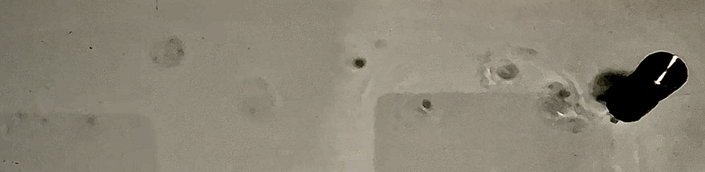

In other cases, this was a lot more difficult (*Note: gamma has been adjusted a lot in the below image to increase visibility*):

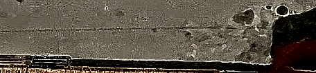

As such, the vortex counts should be treated as rough estimates at best. In spite of this, as we will see later, the results appear aligned with the literature.

### Velocity overview

```r
velocity_overview <- purrr::imap_dfr(tracker_dfs, function(df_video, file_name) {
  tibble(
    video_file = file_name,
    mean_velocity = mean(df_video$v, na.rm = TRUE),
    sd_velocity = sd(df_video$v, na.rm = TRUE)
  )
})

velocity_overview
```

```
## # A tibble: 7 × 3
##   video_file                                           mean_velocity sd_velocity
##   <chr>                                                        <dbl>       <dbl>
## 1 med_hand_jamt_drag_middels_hastighet_2.csv                  0.121       0.0307
## 2 med_hand_jamt_drag_382_671.txt                              0.0877      0.0632
## 3 med_hand_jamt_drag_middels_hastighet_222_408.txt            0.123       0.0321
## 4 med_hand_jamt_drag_middels-hoy_hastighet_095_295.txt        0.118       0.0344
## 5 med_trad_jamt_og_langt_drag__335.txt                        0.123       0.0737
## 6 med_trad_okHastighet_langt_drag__389.txt                    0.0886      0.0272
## 7 med_trad_okHastighet_1_315.txt                              0.0794      0.0205
```

### Summary dataframe per video

```r
# Setup values
characteristic_length_m   <- 0.03   # cylinder diameter diameter in meters
kinematic_viscosity_m2_s  <- 1e-6   # water at ~20 C


summary_df <- purrr::imap_dfr(tracker_dfs, function(df_video, file_name) {
  fallback_index <- match(file_name, names(tracker_dfs))

  mean_velocity <- mean(df_video$v, na.rm = TRUE)
  time_s <- max(df_video$t, na.rm = TRUE) - min(df_video$t, na.rm = TRUE)

  manual_count <- unique(stats::na.omit(df_video$manual_vortex_count))
  manual_count <- if (length(manual_count) > 0) manual_count[[1]] else NA_real_

  total_vorticies <- if (!is.na(manual_count)) {
    as.numeric(manual_count)
  }

  #Calculating dimensionless groups
  shedding_frequency_hz <- (total_vorticies / 2) / time_s
  Re <- (mean_velocity * characteristic_length_m) / kinematic_viscosity_m2_s
  St <- (shedding_frequency_hz * characteristic_length_m) / mean_velocity

  tibble(
    run_number = fallback_index,
    video_index = extract_video_index(file_name, fallback_index),
    video_file = file_name,
    mean_velocity = mean_velocity,
    total_vorticies = total_vorticies,
    time = time_s,
    Re = Re,
    St = St
  )
})

summary_df
```

```
## # A tibble: 7 × 8
##   run_number video_index video_file    mean_velocity total_vorticies  time    Re
##        <int>       <int> <chr>                 <dbl>           <dbl> <dbl> <dbl>
## 1          1           2 med_hand_jam…        0.121               11  6.46 3629.
## 2          2         671 med_hand_jam…        0.0877               9  9.36 2630.
## 3          3         408 med_hand_jam…        0.123               10  6.20 3694.
## 4          4         295 med_hand_jam…        0.118                9  6.66 3529.
## 5          5         335 med_trad_jam…        0.123               13  8.26 3695.
## 6          6         389 med_trad_okH…        0.0886              12  9.33 2659.
## 7          7         315 med_trad_okH…        0.0794               8  4.56 2383.
## # ℹ 1 more variable: St <dbl>
```

### Plotting and visualization

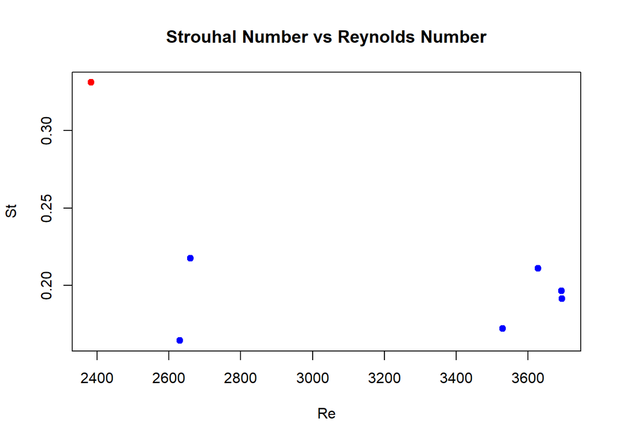

```r
plot(
  x = summary_df$Re,
  y = summary_df$St,
  pch = 19,
  col = "blue",
  xlab = "Re",
  ylab = "St",
  main = "Strouhal Number vs Reynolds Number"
)

#Adding a red point for the outlier
points(
  x = summary_df$Re[summary_df$run_number == 7],
  y = summary_df$St[summary_df$run_number == 7],
  pch = 19,
  col = "red"
)
```

### Correlation

As St is reported as approximately constant over the range of reynolds numbers seen in our data (Roshko, 1954), we expect a Pearsons correlation coefficient close to 0. We will do this with and without the outlier (red dot in above plot). (*Note, cor.test also calculates p values ect*)

```r
#With outlier
cor.test(summary_df$Re, summary_df$St)
```

```
##
##  Pearson's product-moment correlation
##
## data:  summary_df$Re and summary_df$St
## t = -1.4042, df = 5, p-value = 0.2192
## alternative hypothesis: true correlation is not equal to 0
## 95 percent confidence interval:
##  -0.9174451  0.3690489
## sample estimates:
##        cor
## -0.5318063
```

```r
#Without outlier
cor.test(summary_df$Re[summary_df$run_number != 7], summary_df$St[summary_df$run_number != 7])
```

```
##
##  Pearson's product-moment correlation
##
## data:  summary_df$Re[summary_df$run_number != 7] and summary_df$St[summary_df$run_number != 7]
## t = 0.20031, df = 4, p-value = 0.851
## alternative hypothesis: true correlation is not equal to 0
## 95 percent confidence interval:
##  -0.7745488  0.8430349
## sample estimates:
##       cor
## 0.0996551
```

*Correlation is value below “cor” in above output*

We see that without the outlier, we get a correlation close to 0 - in line with what we would expect, while with the outlier the best fit curve has a pronounced negative slope. Note that in either case we do not have the statistical power (n=7) to say that either correlation is meaningfully (p < 0.05) different from 0.

### Ensemble averaging - Results

As the Strohaul Number in the irregular range ($300 < Re < 10^4$) is reported to be approximately constant compared to Re (Roshko, 1954), the differences in Re between the runs can be ignored and we can take the ensemble average over all runs to approximate St. As with the previous cell, this will be done with and without the outlier.

```r
outlier_run_number <- 7

ensemble_with_outlier <- summary_df %>%
  summarise(
    mean_velocity = mean(mean_velocity, na.rm = TRUE),
    mean_Re = mean(Re, na.rm = TRUE),
    mean_St = mean(St, na.rm = TRUE),
    n_runs = dplyr::n()
  ) %>%
  mutate(comment = "With outlier run")

ensemble_without_outlier <- summary_df %>%
  filter(run_number != outlier_run_number) %>%
  summarise(
    mean_velocity = mean(mean_velocity, na.rm = TRUE),
    mean_Re = mean(Re, na.rm = TRUE),
    mean_St = mean(St, na.rm = TRUE),
    n_runs = dplyr::n()
  ) %>%
  mutate(comment = "Without outlier run")

ensemble_results <- bind_rows(ensemble_with_outlier, ensemble_without_outlier) %>%
  select(comment, n_runs, mean_velocity, mean_Re, mean_St)

ensemble_results
```

```
## # A tibble: 2 × 5
##   comment             n_runs mean_velocity mean_Re mean_St
##   <chr>                <int>         <dbl>   <dbl>   <dbl>
## 1 With outlier run         7         0.106   3174.   0.212
## 2 Without outlier run      6         0.110   3306.   0.192
```

### Using bootstrapping for confidence interval

**Assuming my runs are representative of the underlying population**, we can use bootstrapping - i.e random resampling from our “representative” dataset to generate new samples (virtual draws) of the population - estimate the confidence interval. This will be done using the boot library in R.

```r
bootstrap_mean_draws <- function(x, R = 10000, seed = 42) {
  x <- x[!is.na(x)]

  if (length(x) < 2) {
    return(numeric(0))
  }

  mean_stat <- function(data, indices) {
    mean(data[indices])
  }

  set.seed(seed)
  boot_obj <- boot::boot(
    data = x,
    statistic = mean_stat,
    R = R,
    sim = "ordinary"
  )

  as.numeric(boot_obj$t)
}

bootstrap_ci_row <- function(x, boot_draws, R, conf = 0.95, comment = "") {
  x <- x[!is.na(x)]
  n <- length(x)

  if (n < 2 || length(boot_draws) == 0) {
    return(tibble::tibble(
      comment = comment,
      method = "Bootstrap percentile CI",
      R = R,
      n = n,
      mean_St = mean(x),
      bootstrap_se = NA_real_,
      ci95_lower = NA_real_,
      ci95_upper = NA_real_
    ))
  }

  alpha <- (1 - conf) / 2
  ci_bounds <- stats::quantile(
    boot_draws,
    probs = c(alpha, 1 - alpha),
    na.rm = TRUE,
    names = FALSE
  )

  tibble::tibble(
    comment = comment,
    method = "Bootstrap percentile CI",
    R = R,
    n = n,
    mean_St = mean(x),
    bootstrap_se = stats::sd(boot_draws),
    ci95_lower = ci_bounds[[1]],
    ci95_upper = ci_bounds[[2]]
  )
}

R_boot <- 10000

st_with_outlier <- summary_df$St
st_without_outlier <- summary_df$St[summary_df$run_number != outlier_run_number]

boot_draws_with_outlier <- bootstrap_mean_draws(st_with_outlier, R = R_boot, seed = 42)
boot_draws_without_outlier <- bootstrap_mean_draws(st_without_outlier, R = R_boot, seed = 43)

ci_with_outlier <- bootstrap_ci_row(
  x = st_with_outlier,
  boot_draws = boot_draws_with_outlier,
  R = R_boot,
  conf = 0.95,
  comment = "With outlier run"
)

ci_without_outlier <- bootstrap_ci_row(
  x = st_without_outlier,
  boot_draws = boot_draws_without_outlier,
  R = R_boot,
  conf = 0.95,
  comment = "Without outlier run"
)

ci_results <- bind_rows(ci_with_outlier, ci_without_outlier) %>%
  select(comment, method, R, n, mean_St, bootstrap_se, ci95_lower, ci95_upper)

ci_results
```

```
## # A tibble: 2 × 8
##   comment          method     R     n mean_St bootstrap_se ci95_lower ci95_upper
##   <chr>            <chr>  <dbl> <int>   <dbl>        <dbl>      <dbl>      <dbl>
## 1 With outlier run Boots… 10000     7   0.212      0.0197       0.182      0.256
## 2 Without outlier… Boots… 10000     6   0.192      0.00785      0.176      0.207
```

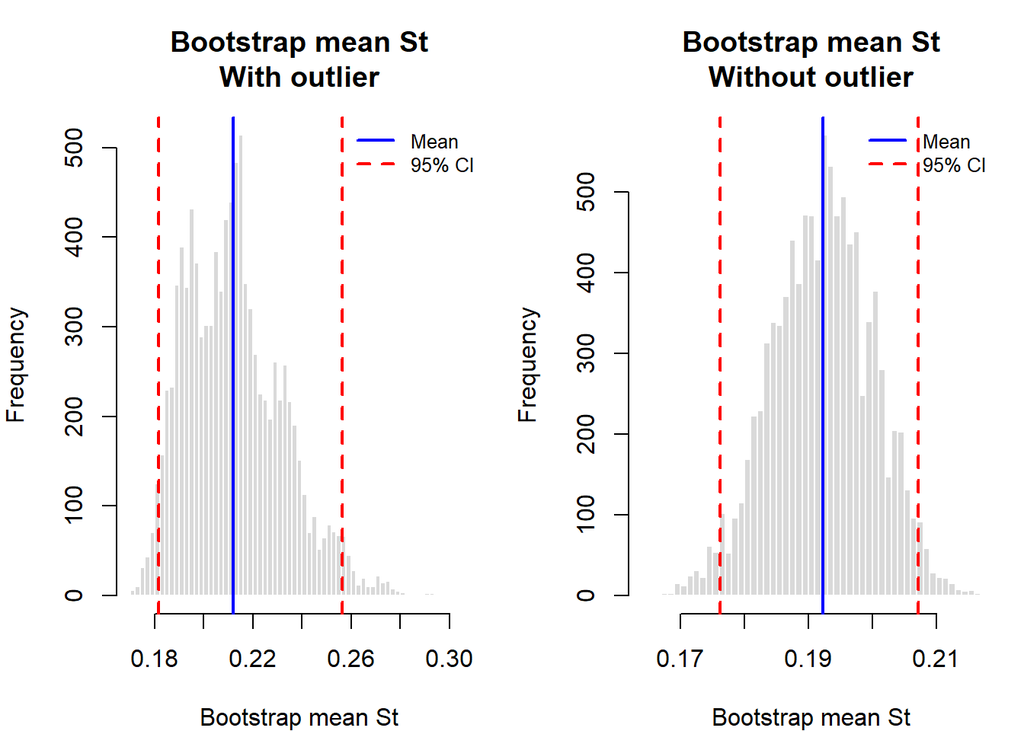

```r
old_par <- par(no.readonly = TRUE)
par(mfrow = c(1, 2), mar = c(4, 4, 4, 1))

hist(
  boot_draws_with_outlier,
  breaks = "FD",
  col = "gray85",
  border = "white",
  main = "Bootstrap mean St\nWith outlier",
  xlab = "Bootstrap mean St"
)
abline(v = ci_with_outlier$mean_St, col = "blue", lwd = 2)
abline(v = c(ci_with_outlier$ci95_lower, ci_with_outlier$ci95_upper), col = "red", lwd = 2, lty = 2)
legend("topright", legend = c("Mean", "95% CI"), col = c("blue", "red"), lwd = 2, lty = c(1, 2), bty = "n", cex = 0.8)

hist(
  boot_draws_without_outlier,
  breaks = "FD",
  col = "gray85",
  border = "white",
  main = "Bootstrap mean St\nWithout outlier",
  xlab = "Bootstrap mean St"
)
abline(v = ci_without_outlier$mean_St, col = "blue", lwd = 2)
abline(v = c(ci_without_outlier$ci95_lower, ci_without_outlier$ci95_upper), col = "red", lwd = 2, lty = 2)
legend("topright", legend = c("Mean", "95% CI"), col = c("blue", "red"), lwd = 2, lty = c(1, 2), bty = "n", cex = 0.8)
```

### Discussion

Based on the data in Roshko (1954), we expect a St number around 0.21, which is within the 95% confidence interval when we include the outlier, and just outside the confidence interval without the outlier (*note: but not outside both if confidence intervals are found assuming an underlying normal distribution*). As I believe the outlier result to be wrong - due to being so far outside of what is found in the literature, probably due to erroneous counting on my part - our result being below what is commonly reported in the literature might indicate a bias in my counting method, or be the result of other systematic factors in the way the experiment was performed. One possibility is that due to the short pull distance, the vortex streets are not fully developed at the start of each video.

A final note on the distributions: As expected due the law of large numbers, both distributions appear approximately normal, but interestingly we see some skewness (and twin peaks) in the distribution that includes the outlier. This could possibly support my suspicion that this is truly an outlier, take as meaning that it belongs to a different population than the other runs. It could also be that my sample size is too small, breaking the assumption of representativeness that bootstrapping relies on, and that the distribution would smooth out if more runs would have been included in the dataset.

### References

Roshko, Anatol. 1954. ‘On the Development of Turbulent Wakes from Vortex Streets’. Available at: https://ntrs.nasa.gov/citations/19930092207